# Assignment 1

## Author : Tirth Jignesh Raval

## Student ID : 400487318

## Email : ravalt1@mcmaster.ca

## Sarah Trainer's Data Preprocessing and Reporting

## Section 1 : Loading the Essential Libraries

Loading all Libraries in the Beginning

```python
import pandas as pd
import numpy as np
import matplotlib.pyplot as plt
import plotly.express as px
import plotly.io as pio
pio.renderers.default = "notebook_connected"
print("All Libraries Loaded Successfully")
```

```
All Libraries Loaded Successfully
```

## Section 2 : Importing the Data

Importing the Raw Data into the Python Environment using pandas

```python
data = pd.read_csv("Assignment1.csv")
# Visualizing the top few rows for confirming successful load of the raw data
data.head(7)
```

|  | FirstName | LastName | Email | ACCOUNT_ID | LATEST_TRANSACTION_ID | COUNTRY | REGION | SALES_LEADER | SALES_VICE_PRESIDENT | ACCOUNT_AGE_YEARS | YTD_SALES | PRE_YTD_SALES | CUSTOMER_CATEGORY |
| --- | --- | --- | --- | --- | --- | --- | --- | --- | --- | --- | --- | --- | --- |
| 0 | Dominykas | Kline | Dominykas.Kline@fakeemailaddress.com | CID360007AAQ | ID627830CDG | US | US EAST | Nicole Stamp | Hattie Beattie | 6 | 1.85868 | 1.87726 | End Customer |
| 1 | Myra | Mcintosh | Myra.Mcintosh@fakeemailaddress.com | CID766149AAQ | ID744031CDG | CA | CA EAST | Iram Luna | Adem Osborne | 3 | 1.91772 | 1.85133 | End Customer |
| 2 | Talhah | Molina | Talhah.Molina@fakeemailaddress.com | CID123310AAQ | ID423991CDG | US | US WEST | Taliah Pope | Matas Walmsley | 8 | 41.98922 | 52.43973 | Corporate |
| 3 | Cecily | Irvine | Cecily.Irvine@fakeemailaddress.com | CID401337AAQ | ID133818CDG | CA | CA EAST | Iram Luna | Adem Osborne | 9 | 1.66511 | 2.08948 | End Customer |
| 4 | Donte | Monroe | Donte.Monroe@fakeemailaddress.com | CID849996AAQ | ID293826CDG | US | US EAST | Nicole Stamp | Hattie Beattie | 5 | 2.20341 | 1.33336 | End Customer |
| 5 | Tiernan | Salt | Tiernan.Salt@fakeemailaddress.com | CID335035AAQ | ID967560CDG | US | US WEST | Taliah Pope | Matas Walmsley | 5 | 40.95618 | 83.85628 | Reseller |
| 6 | Lance | Jacobs | Lance.Jacobs@fakeemailaddress.com | CID749634AAQ | ID144206CDG | CA | CA WEST | Zaid Nunez | Esa Walton | 7 | 2.04947 | 0.84330 | End Customer |

```python
data.tail(6)
```

|  | FirstName | LastName | Email | ACCOUNT_ID | LATEST_TRANSACTION_ID | COUNTRY | REGION | SALES_LEADER | SALES_VICE_PRESIDENT | ACCOUNT_AGE_YEARS | YTD_SALES | PRE_YTD_SALES | CUSTOMER_CATEGORY |
| --- | --- | --- | --- | --- | --- | --- | --- | --- | --- | --- | --- | --- | --- |
| 98 | Fleur | Ellis | Fleur.Ellis@fakeemailaddress.com | CID816592AAQ | ID910142CDG | US | US EAST | Nicole Stamp | Hattie Beattie | 5 | 0.92872 | 1.32992 | End Customer |
| 99 | Tracey | Keller | Tracey.Keller@fakeemailaddress.com | CID897317AAQ | ID546762CDG | US | US WEST | Taliah Pope | Matas Walmsley | 8 | 158.56185 | 102.39043 | Reseller |
| 100 | Sammy-Jo | Reese | Sammy-Jo.Reese@fakeemailaddress.com | CID993911AAQ | ID828692CDG | CA | NaN | Shahzaib Mahoney | Adem Osborne | 5 | 2.18845 | 1.07357 | End Customer |
| 101 | Kiaan | Wilde | Kiaan.Wilde@fakeemailaddress.com | CID859909AAQ | ID850690CDG | CA | CA EAST | Iram Luna | Adem Osborne | 9 | NaN | 1.02099 | End Customer |
| 102 | Tahlia | Hyde | Tahlia.Hyde@fakeemailaddress.com | CID438320AAQ | ID912821CDG | CA | CA EAST | Shahzaib Mahoney | Adem Osborne | 5 | 148.28950 | 104.20998 | Reseller |
| 103 | Dewey | Vargas | Dewey.Vargas@fakeemailaddress.com | CID137942AAQ | ID667230CDG | CA | CA EAST | Shahzaib Mahoney | Adem Osborne | 6 | 1.94849 | 1.00363 | End Customer |

We can confirm visually that Data has been loaded successfully in the python notebook/environment

## Section 3 : Understanding the Basic Layout of the dataset

General Shape of the dataset

```python
data.shape
```

```
(104, 13)
```

There are 104 records in the data set and there 13 columns associated with the data

```python
data.info()
```

```
<class 'pandas.core.frame.DataFrame'>
RangeIndex: 104 entries, 0 to 103
Data columns (total 13 columns):
 #   Column                 Non-Null Count  Dtype
---  ------                 --------------  -----
 0   FirstName              103 non-null    object
 1   LastName               104 non-null    object
 2   Email                  104 non-null    object
 3   ACCOUNT_ID             104 non-null    object
 4   LATEST_TRANSACTION_ID  104 non-null    object
 5   COUNTRY                104 non-null    object
 6   REGION                 102 non-null    object
 7   SALES_LEADER           104 non-null    object
 8   SALES_VICE_PRESIDENT   104 non-null    object
 9   ACCOUNT_AGE_YEARS      104 non-null    int64
 10  YTD_SALES              102 non-null    float64
 11  PRE_YTD_SALES          103 non-null    float64
 12  CUSTOMER_CATEGORY      104 non-null    object
dtypes: float64(2), int64(1), object(10)
memory usage: 10.7+ KB
```

Some columns in the dataset seems to have **Null Values** Those columns are

1. FirstName
2. REGION
3. YTD_SALES
4. PRE_YTD_SALES

Lets count how many null values does these columns have

```python
data.isnull().sum()
```

```
FirstName                1
LastName                 0
Email                    0
ACCOUNT_ID               0
LATEST_TRANSACTION_ID    0
COUNTRY                  0
REGION                   2
SALES_LEADER             0
SALES_VICE_PRESIDENT     0
ACCOUNT_AGE_YEARS        0
YTD_SALES                2
PRE_YTD_SALES            1
CUSTOMER_CATEGORY        0
dtype: int64
```

```python
data[["FirstName","REGION","YTD_SALES","PRE_YTD_SALES"]].isnull().sum()
```

```
FirstName        1
REGION           2
YTD_SALES        2
PRE_YTD_SALES    1
dtype: int64
```

These 4 columns are

1. FirstName - 1 Missing Value
2. REGION - 2 Missing Values
3. YTD_SALES - 2 Missing Values
4. PRE_YTD_SALES - 1 Missing Value

**We shall keep into consideration to treat the missing values when we enter to preprocess them**

Basic Summary of the data set

```python
data.describe()
```

|  | ACCOUNT_AGE_YEARS | YTD_SALES | PRE_YTD_SALES |
| --- | --- | --- | --- |
| count | 104.000000 | 102.000000 | 103.000000 |
| mean | 5.201923 | 29.880579 | 22.932338 |
| std | 2.187253 | 51.518375 | 46.831163 |
| min | 1.000000 | 0.928720 | -10.463100 |
| 25% | 4.000000 | 1.911277 | 1.168625 |
| 50% | 5.000000 | 2.344200 | 1.686880 |
| 75% | 6.250000 | 43.359327 | 24.320515 |
| max | 11.000000 | 223.592490 | 227.743870 |

It is important to note that the **min value in PRE_YTD_SALES is less than zero or -ve** which is beyond expectation. As sales cant be negative. We need to investigate that as well

## Section 4 : Data Pre-Processing

There are two ways to pre-process the data in this case.

1. Process by Type of Checks - Such as Null, Unique, Leading Spaces etc..
2. Process Column - by - Column i.e. Checking whether each column follows the properites associated with it.

As there are limited 13 columns in the dataset, we can proceed with the 2nd Option to be on the safer side.

Below is the image of list of columns with the set of properties associated with each of them

[figure not shown]

**Note - Each Color indicates a type of check need to be performed on that column.**

1. Red - Blank Check
2. Blue - Spaces or Leading Spaces
3. Green - Naming Convention / Protocol or Checking Values against a desired set of values
4. Grey - Checking whether the value is +ve
5. Pink - LengthCheck of value in that cell

#### Columns First Name, Last Name and Email - They share same properties

Also the "First Name" also have **Null Values**

Dropping Null Values could be the only solution for this column **However** we could use Email Address first Part to replace the values

```python
data["FirstName"].isna().sum()
# There is one missing value in this column
```

```
1
```

```python
for i in data.index:
    if type(data.loc[i,"FirstName"]) != str:
        print(type(data.loc[i,"FirstName"]))
```

```
<class 'float'>
```

Here we can find that the null value is classified as float instead of a string. So we shall replace this value with the First Part of the Email Address of the same index

```python
for i in data.index:
    if type(data.loc[i,"FirstName"]) == float:
        data.loc[i,"FirstName"] = data.loc[i,"Email"].split(".")[0]
```

```python
data["FirstName"].isna().sum()
```

```
0
```

We have successfully replaced the missing value in this column. Now we need to investigate if First Name, Last Name and Email have spaces. In case of spaces we need to trim that

```python
for i in ["FirstName","LastName","Email"]:
    print(i,data[i].str.contains(" ").sum())
```

```
FirstName 0
LastName 0
Email 2
```

We can see here that **Email have Whitespaces in their records**. Thus we need to trim those null values

```python
data["Email"] =  data["Email"].str.replace(" ","")
for i in ["FirstName","LastName","Email"]:
    print(i,data[i].str.contains(" ").sum())
```

```
FirstName 0
LastName 0
Email 0
```

Now all these columns Does not contains Space. Thus columns FirstName, LastName, Email have no missing values and no spaces in them

#### Columns ACCOUNT_ID, LATEST_TRANSACTION_ID - They share same properties

Only there is difference in length

We need to check whether these columns are unique or not.

```python
data.duplicated(subset=["ACCOUNT_ID","LATEST_TRANSACTION_ID"]).sum()
```

```
4
```

```python
data[["ACCOUNT_ID","LATEST_TRANSACTION_ID"]].value_counts(ascending=False)
```

```
ACCOUNT_ID    LATEST_TRANSACTION_ID
CID331788AAQ  ID126292CDG              2
CID144086AAQ  ID795668CDG              2
CID897317AAQ  ID546762CDG              2
CID262320AAQ  ID117469CDG              2
CID102798AAQ  ID769296CDG              1
                                      ..
CID390599AAQ  ID348560CDG              1
CID388479AAQ  ID726056CDG              1
CID383325AAQ  ID500684CDG              1
CID382003AAQ  ID564180CDG              1
ID645881CDG   CID384026AAQ             1
Length: 100, dtype: int64
```

We could see that these 4 Account and Transaction have 2 rows. ACCOUNT_ID LATEST_TRANSACTION_ID CID331788AAQ ID126292CDG 2 CID144086AAQ ID795668CDG 2 CID897317AAQ ID546762CDG 2 CID262320AAQ ID117469CDG 2

**Note it could be the case that one account have multiple transaction ID but both cannot be same**

So there are 4 instances where these are duplicated. Lets look into those instances

```python
# These 4 rows are duplicated
data[data.duplicated(subset=["ACCOUNT_ID","LATEST_TRANSACTION_ID"])]
```

|  | FirstName | LastName | Email | ACCOUNT_ID | LATEST_TRANSACTION_ID | COUNTRY | REGION | SALES_LEADER | SALES_VICE_PRESIDENT | ACCOUNT_AGE_YEARS | YTD_SALES | PRE_YTD_SALES | CUSTOMER_CATEGORY |
| --- | --- | --- | --- | --- | --- | --- | --- | --- | --- | --- | --- | --- | --- |
| 76 | Amelia-Rose | Shelton | Amelia-Rose.Shelton@fakeemailaddress.com | CID144086AAQ | ID795668CDG | CA | CA EAST | Iram Luna | Adem Osborne | 7 | 47.84119 | 27.38527 | Corporate |
| 83 | Francesco | Malone | Francesco.Malone@fakeemailaddress.com | CID262320AAQ | ID117469CDG | CA | CA EAST | Iram Luna | Adem Osborne | 5 | 1.27467 | 0.97165 | End Customer |
| 91 | Devante | Carney | Devante.Carney@fakeemailaddress.com | CID331788AAQ | ID126292CDG | US | US WEST | Taliah Pope | Matas Walmsley | 9 | 2.12987 | 0.40810 | End Customer |
| 99 | Tracey | Keller | Tracey.Keller@fakeemailaddress.com | CID897317AAQ | ID546762CDG | US | US WEST | Taliah Pope | Matas Walmsley | 8 | 158.56185 | 102.39043 | Reseller |

We should drop these 4 duplicated rows.

```python
data.drop_duplicates(subset=["ACCOUNT_ID","LATEST_TRANSACTION_ID"],keep="first",inplace=True)
data[["ACCOUNT_ID","LATEST_TRANSACTION_ID"]].value_counts(ascending=False)
```

```
ACCOUNT_ID    LATEST_TRANSACTION_ID
CID102798AAQ  ID769296CDG              1
CID696948AAQ  ID391296CDG              1
CID769746AAQ  ID889085CDG              1
CID766149AAQ  ID744031CDG              1
CID764908AAQ  ID326192CDG              1
                                      ..
CID382003AAQ  ID564180CDG              1
CID373243AAQ  ID649540CDG              1
CID362395AAQ  ID631788CDG              1
CID360007AAQ  ID627830CDG              1
ID645881CDG   CID384026AAQ             1
Length: 100, dtype: int64
```

Now the Duplicate Rows have been dropped. Thus the unique property has been satisified. As we have dropped the row we shall also reset the indexes.

```python
data.reset_index(drop=True,inplace=True)
data.shape
```

```
(100, 13)
```

#### Checking Regex Match for Account ID

```python
data["ACCOUNT_ID"].str.contains('CID[0-9]{6}AAQ').sum()
```

```
99
```

That means 99 records follow the protocol however one record has some challenges. We need to investigate what is wrong with that record.

```python
data[~data["ACCOUNT_ID"].str.contains('CID[0-9]{6}AAQ')]
```

|  | FirstName | LastName | Email | ACCOUNT_ID | LATEST_TRANSACTION_ID | COUNTRY | REGION | SALES_LEADER | SALES_VICE_PRESIDENT | ACCOUNT_AGE_YEARS | YTD_SALES | PRE_YTD_SALES | CUSTOMER_CATEGORY |
| --- | --- | --- | --- | --- | --- | --- | --- | --- | --- | --- | --- | --- | --- |
| 18 | Ella-Grace | House | Ella-Grace.House@fakeemailaddress.com | ID645881CDG | CID384026AAQ | US | US EAST | Nicole Stamp | Hattie Beattie | 6 | 20.72854 | -10.4631 | Corporate |

#### Checking Regex Match for Last Transaction ID

```python
data["LATEST_TRANSACTION_ID"].str.contains('ID[0-9]{6}CDG').sum()
```

```
99
```

That means 99 records follow the protocol however one record has some challenges. We need to investigate what is wrong with that record.

```python
data[~data["LATEST_TRANSACTION_ID"].str.contains('ID[0-9]{6}CDG')]
```

|  | FirstName | LastName | Email | ACCOUNT_ID | LATEST_TRANSACTION_ID | COUNTRY | REGION | SALES_LEADER | SALES_VICE_PRESIDENT | ACCOUNT_AGE_YEARS | YTD_SALES | PRE_YTD_SALES | CUSTOMER_CATEGORY |
| --- | --- | --- | --- | --- | --- | --- | --- | --- | --- | --- | --- | --- | --- |
| 18 | Ella-Grace | House | Ella-Grace.House@fakeemailaddress.com | ID645881CDG | CID384026AAQ | US | US EAST | Nicole Stamp | Hattie Beattie | 6 | 20.72854 | -10.4631 | Corporate |

The same record is causing this mistake. **The values seems to be interchanged while typing**. Thus we shall correct them by exchanging the values

```python
for i in data[~data["LATEST_TRANSACTION_ID"].str.contains('ID[0-9]{6}CDG')].index:
    data.loc[i,"LATEST_TRANSACTION_ID"],data.loc[i,"ACCOUNT_ID"] = data.loc[i,"ACCOUNT_ID"],data.loc[i,"LATEST_TRANSACTION_ID"]
```

```python
data["LATEST_TRANSACTION_ID"].str.contains('ID[0-9]{6}CDG').sum()
```

```
100
```

```python
data["ACCOUNT_ID"].str.contains('CID[0-9]{6}AAQ').sum()
```

```
100
```

Thus the values have been swapped and both follow their own protocol and length

#### Lets now inspect the "COUNTRY" variable

the variable could be either CA or US

```python
data["COUNTRY"].value_counts()
```

```
US     50
CA     49
CAN     1
Name: COUNTRY, dtype: int64
```

CAN shall be replaced to CA

```python
data["COUNTRY"].replace("CAN","CA",inplace=True)
data["COUNTRY"].value_counts()
```

```
US    50
CA    50
Name: COUNTRY, dtype: int64
```

The COUNTRY Variable is now in perfect shape

#### Lets now inspect the "REGION","SALES_LEADER" and "SALES_VICE_PRESIDENT" columns

they are linked with one another using the ORG Structure Thus we need the org Structure

[figure not shown]

We know that "Region" have Null Values in them which shall be filled using their associated Sales VP.

**For Filling Region we need to First Inspect "SALES_VICE_PRESIDENT" & "SALES_LEADER"**

```python
data.info()
```

```
<class 'pandas.core.frame.DataFrame'>
RangeIndex: 100 entries, 0 to 99
Data columns (total 13 columns):
 #   Column                 Non-Null Count  Dtype
---  ------                 --------------  -----
 0   FirstName              100 non-null    object
 1   LastName               100 non-null    object
 2   Email                  100 non-null    object
 3   ACCOUNT_ID             100 non-null    object
 4   LATEST_TRANSACTION_ID  100 non-null    object
 5   COUNTRY                100 non-null    object
 6   REGION                 98 non-null     object
 7   SALES_LEADER           100 non-null    object
 8   SALES_VICE_PRESIDENT   100 non-null    object
 9   ACCOUNT_AGE_YEARS      100 non-null    int64
 10  YTD_SALES              98 non-null     float64
 11  PRE_YTD_SALES          99 non-null     float64
 12  CUSTOMER_CATEGORY      100 non-null    object
dtypes: float64(2), int64(1), object(10)
memory usage: 10.3+ KB
```

We know that SALES_LEADER and SALES_VICE_PRESIDENT are not blank. We need to check for leading spaces and check if they follow the structure

```python
data["SALES_LEADER"].str.contains('/s[a-z,A-Z]*/s').sum()
```

```
0
```

```python
data["SALES_VICE_PRESIDENT"].str.contains('/s[a-z,A-Z]*/s').sum()
```

```
0
```

```python
data["SALES_VICE_PRESIDENT"].value_counts()
```

```
Adem Osborne      38
Hattie Beattie    34
Matas Walmsley    15
Esa Walton        12
Zaid Nunez         1
Name: SALES_VICE_PRESIDENT, dtype: int64
```

```python
data["SALES_LEADER"].value_counts()
```

```
Nicole Stamp        34
Iram Luna           25
Shahzaib Mahoney    13
Taliah Pope         12
Zaid Nunez          12
Atlanta Avila        3
Esa Walton           1
Name: SALES_LEADER, dtype: int64
```

```python
data["Leader-VP-Match"] = ''
leadvp_dict={
    "Adem Osborne" : ["Shahzaib Mahoney","Iram Luna"],
    "Esa Walton" : ["Zaid Nunez"],
    "Matas Walmsley":["Taliah Pope","Atlanta Avila"],
    "Hattie Beattie":["Nicole Stamp"]
}
for i in data.index:
    try:
        if data.loc[i,"SALES_LEADER"] in leadvp_dict[data.loc[i,"SALES_VICE_PRESIDENT"]]:
            data.loc[i,"Leader-VP-Match"] = True
    except KeyError:
        data.loc[i,"Leader-VP-Match"] = False
data["Leader-VP-Match"].value_counts()
```

```
True     99
False     1
Name: Leader-VP-Match, dtype: int64
```

##### We could see here that one leader VP Match is incorrect. Let us investigate this in detail.

```python
data[data["Leader-VP-Match"]==False]
```

|  | FirstName | LastName | Email | ACCOUNT_ID | LATEST_TRANSACTION_ID | COUNTRY | REGION | SALES_LEADER | SALES_VICE_PRESIDENT | ACCOUNT_AGE_YEARS | YTD_SALES | PRE_YTD_SALES | CUSTOMER_CATEGORY | Leader-VP-Match |
| --- | --- | --- | --- | --- | --- | --- | --- | --- | --- | --- | --- | --- | --- | --- |
| 61 | Jillian | Madden | Jillian.Madden@fakeemailaddress.com | CID125265AAQ | ID833798CDG | CA | CA WEST | Esa Walton | Zaid Nunez | 5 | 1.78356 | 0.88224 | End Customer | False |

It is evident that Sales Leader and Sales VP names have been exchanged. We need to **Interchange them**

```python
for i in data[data["Leader-VP-Match"]==False].index:
    data.loc[i,"SALES_VICE_PRESIDENT"], data.loc[i,"SALES_LEADER"] = data.loc[i,"SALES_LEADER"],data.loc[i,"SALES_VICE_PRESIDENT"]
for i in data.index:
    try:
        if data.loc[i,"SALES_LEADER"] in leadvp_dict[data.loc[i,"SALES_VICE_PRESIDENT"]]:
            data.loc[i,"Leader-VP-Match"] = True
    except KeyError:
        data.loc[i,"Leader-VP-Match"] = False
data["Leader-VP-Match"].value_counts()
```

```
True    100
Name: Leader-VP-Match, dtype: int64
```

##### Now All the VP and Leaders match so we can now drop the Leader-VP-Match Work on Filling up the Missing Values of the Region

```python
data.drop(columns=["Leader-VP-Match"], axis=1,inplace=True)
data["REGION"].isnull().sum()
```

```
2
```

Thus there are 2 null values We need to see those two rows

```python
data[data["REGION"].isnull()]
```

|  | FirstName | LastName | Email | ACCOUNT_ID | LATEST_TRANSACTION_ID | COUNTRY | REGION | SALES_LEADER | SALES_VICE_PRESIDENT | ACCOUNT_AGE_YEARS | YTD_SALES | PRE_YTD_SALES | CUSTOMER_CATEGORY |
| --- | --- | --- | --- | --- | --- | --- | --- | --- | --- | --- | --- | --- | --- |
| 89 | Franco | Sandoval | Franco.Sandoval@fakeemailaddress.com | CID847477AAQ | ID818730CDG | US | NaN | Nicole Stamp | Hattie Beattie | 4 | 219.33388 | 106.69252 | Reseller |
| 96 | Sammy-Jo | Reese | Sammy-Jo.Reese@fakeemailaddress.com | CID993911AAQ | ID828692CDG | CA | NaN | Shahzaib Mahoney | Adem Osborne | 5 | 2.18845 | 1.07357 | End Customer |

Let us see if we have any other issues with REGION.

```python
data["REGION"].value_counts()
```

```
CA EAST    36
US EAST    33
US WEST    15
CA WEST    13
CA EST      1
Name: REGION, dtype: int64
```

Here we can see that the CA EAST and CA EST is misspelled. So the following code shall rename those for us

```python
vpregion_dict = {
    "Adem Osborne" : "CA EAST",
    "Esa Walton" : "CA WEST",
    "Matas Walmsley":"US WEST",
    "Hattie Beattie":"US EAST"
}
for i in data.index:
    if data.loc[i,"REGION"] != vpregion_dict[data.loc[i,"SALES_VICE_PRESIDENT"]]:
        data.loc[i,"REGION"] = vpregion_dict[data.loc[i,"SALES_VICE_PRESIDENT"]]
data["REGION"].value_counts()
```

```
CA EAST    38
US EAST    34
US WEST    15
CA WEST    13
Name: REGION, dtype: int64
```

```python
data["REGION"].isnull().sum()
```

```
0
```

Checking whether the Region matches the country or not

```python
country_region_dict = {
    "US" : ["US WEST","US EAST"],
    "CA" : ["CA EAST","CA WEST"]
}
for i in data.index:
    if data.loc[i,"REGION"] not in country_region_dict[data.loc[i,"COUNTRY"]]:
        print(data.loc[i,["REGION","COUNTRY","SALES_VICE_PRESIDENT"]])
        print(i)
```

```
REGION                       CA EAST
COUNTRY                           US
SALES_VICE_PRESIDENT    Adem Osborne
Name: 92, dtype: object
92
```

We can see here that the Sales VP Adem Osborne is associated with it who operates in CA EAST so the Country is CA instead of US.

```python
# Could also be done using a dict but I am changing manually here...
data.loc[92,"COUNTRY"] = "CA"
```

Now we have successfully cleaned the "REGION","SALES_LEADER" and "SALES_VICE_PRESIDENT" columns

The **CUSTOMER_CATEGORY share the similiar property as Region**. i.e. Must not be Blank and Should either be End Customer, Corporate , or Reseller

```python
data["CUSTOMER_CATEGORY"].isnull().sum()
```

```
0
```

##### There are no Null Values in the CUSTOMER_CATEGORY Columns

```python
data["CUSTOMER_CATEGORY"].value_counts()
```

```
End Customer    67
Corporate       21
Reseller        12
Name: CUSTOMER_CATEGORY, dtype: int64
```

These values are same as expected. Hence the Column "CUSTOMER_CATEGORY" is in **Perfect Condition**

#### Inspecting Numerical Columns "ACCOUNT_AGE_YEARS", "YTD_SALES" , "PRE_YTD_SALES"

```python
data["ACCOUNT_AGE_YEARS"].isnull().sum()
```

```
0
```

```python
data[["ACCOUNT_AGE_YEARS"]].info()
```

```
<class 'pandas.core.frame.DataFrame'>
RangeIndex: 100 entries, 0 to 99
Data columns (total 1 columns):
 #   Column             Non-Null Count  Dtype
---  ------             --------------  -----
 0   ACCOUNT_AGE_YEARS  100 non-null    int64
dtypes: int64(1)
memory usage: 928.0 bytes
```

##### The ACCOUNT_AGE_YEARS column is not blank is an integer as expected in perfect condition

**We noticed that PRE_YTD_SALES had -ve values** which is not expected. So we shall investigate the same before moving forward

```python
data.describe()
```

|  | ACCOUNT_AGE_YEARS | YTD_SALES | PRE_YTD_SALES |
| --- | --- | --- | --- |
| count | 100.000000 | 98.000000 | 99.000000 |
| mean | 5.120000 | 28.959301 | 22.534094 |
| std | 2.170882 | 50.718082 | 46.987120 |
| min | 1.000000 | 0.928720 | -10.463100 |
| 25% | 4.000000 | 1.911277 | 1.190760 |
| 50% | 5.000000 | 2.344200 | 1.686880 |
| 75% | 6.000000 | 42.882605 | 19.408095 |
| max | 11.000000 | 223.592490 | 227.743870 |

```python
data[data["PRE_YTD_SALES"]<0]
```

|  | FirstName | LastName | Email | ACCOUNT_ID | LATEST_TRANSACTION_ID | COUNTRY | REGION | SALES_LEADER | SALES_VICE_PRESIDENT | ACCOUNT_AGE_YEARS | YTD_SALES | PRE_YTD_SALES | CUSTOMER_CATEGORY |
| --- | --- | --- | --- | --- | --- | --- | --- | --- | --- | --- | --- | --- | --- |
| 11 | Hisham | Ferguson | Hisham.Ferguson@fakeemailaddress.com | CID710001AAQ | ID639088CDG | US | US EAST | Nicole Stamp | Hattie Beattie | 5 | 32.59451 | -8.61102 | Corporate |
| 18 | Ella-Grace | House | Ella-Grace.House@fakeemailaddress.com | CID384026AAQ | ID645881CDG | US | US EAST | Nicole Stamp | Hattie Beattie | 6 | 20.72854 | -10.46310 | Corporate |
| 22 | Bogdan | Driscoll | Bogdan.Driscoll@fakeemailaddress.com | CID479531AAQ | ID978864CDG | CA | CA EAST | Iram Luna | Adem Osborne | 8 | 43.18040 | -0.87961 | Corporate |

##### It expected that the values should not be negative. So in this case we could either drop the records or turn them into +ve values assuming it as a mistake.

**Due to limited number of records we assume that due to mistake -ve values were entered but actually they were positive hence we are turning them into +ve values.**

```python
for i in data[data["PRE_YTD_SALES"]<0].index:
    if data.loc[i,"PRE_YTD_SALES"] < 0:
        data.loc[i,"PRE_YTD_SALES"] = data.loc[i,"PRE_YTD_SALES"] * -1
```

```python
data.describe()
```

|  | ACCOUNT_AGE_YEARS | YTD_SALES | PRE_YTD_SALES |
| --- | --- | --- | --- |
| count | 100.000000 | 98.000000 | 99.000000 |
| mean | 5.120000 | 28.959301 | 22.937200 |
| std | 2.170882 | 50.718082 | 46.789664 |
| min | 1.000000 | 0.928720 | 0.393300 |
| 25% | 4.000000 | 1.911277 | 1.240150 |
| 50% | 5.000000 | 2.344200 | 1.753330 |
| 75% | 6.000000 | 42.882605 | 19.408095 |
| max | 11.000000 | 223.592490 | 227.743870 |

```python
data.info()
```

```
<class 'pandas.core.frame.DataFrame'>
RangeIndex: 100 entries, 0 to 99
Data columns (total 13 columns):
 #   Column                 Non-Null Count  Dtype
---  ------                 --------------  -----
 0   FirstName              100 non-null    object
 1   LastName               100 non-null    object
 2   Email                  100 non-null    object
 3   ACCOUNT_ID             100 non-null    object
 4   LATEST_TRANSACTION_ID  100 non-null    object
 5   COUNTRY                100 non-null    object
 6   REGION                 100 non-null    object
 7   SALES_LEADER           100 non-null    object
 8   SALES_VICE_PRESIDENT   100 non-null    object
 9   ACCOUNT_AGE_YEARS      100 non-null    int64
 10  YTD_SALES              98 non-null     float64
 11  PRE_YTD_SALES          99 non-null     float64
 12  CUSTOMER_CATEGORY      100 non-null    object
dtypes: float64(2), int64(1), object(10)
memory usage: 10.3+ KB
```

We earlier noticed that both "YTD_SALES" , "PRE_YTD_SALES" had null values. The best way to fill null values for numerical columns is their mean.

```python
data["YTD_SALES"].fillna(value=data.YTD_SALES.mean(),inplace=True)
data["PRE_YTD_SALES"].fillna(value=data.PRE_YTD_SALES.mean(),inplace=True)
```

```python
data["PRE_YTD_SALES"].isnull().sum()
```

```
0
```

```python
data["YTD_SALES"].isnull().sum()
```

```
0
```

```python
data.info()
```

```
<class 'pandas.core.frame.DataFrame'>
RangeIndex: 100 entries, 0 to 99
Data columns (total 13 columns):
 #   Column                 Non-Null Count  Dtype
---  ------                 --------------  -----
 0   FirstName              100 non-null    object
 1   LastName               100 non-null    object
 2   Email                  100 non-null    object
 3   ACCOUNT_ID             100 non-null    object
 4   LATEST_TRANSACTION_ID  100 non-null    object
 5   COUNTRY                100 non-null    object
 6   REGION                 100 non-null    object
 7   SALES_LEADER           100 non-null    object
 8   SALES_VICE_PRESIDENT   100 non-null    object
 9   ACCOUNT_AGE_YEARS      100 non-null    int64
 10  YTD_SALES              100 non-null    float64
 11  PRE_YTD_SALES          100 non-null    float64
 12  CUSTOMER_CATEGORY      100 non-null    object
dtypes: float64(2), int64(1), object(10)
memory usage: 10.3+ KB
```

All Columns are in perfect condition and could be used for further analysis.

### Thus the data set is now clean

Let us save this data for future reference. Naming as Assignment1Clean.csv

```python
data.to_csv("Assignment1Clean.csv",index=False)
```

## Section 5 : Insights through Data Visualization

```python
df = pd.read_csv("Assignment1Clean.csv")
df.head()
```

|  | FirstName | LastName | Email | ACCOUNT_ID | LATEST_TRANSACTION_ID | COUNTRY | REGION | SALES_LEADER | SALES_VICE_PRESIDENT | ACCOUNT_AGE_YEARS | YTD_SALES | PRE_YTD_SALES | CUSTOMER_CATEGORY |
| --- | --- | --- | --- | --- | --- | --- | --- | --- | --- | --- | --- | --- | --- |
| 0 | Dominykas | Kline | Dominykas.Kline@fakeemailaddress.com | CID360007AAQ | ID627830CDG | US | US EAST | Nicole Stamp | Hattie Beattie | 6 | 1.85868 | 1.87726 | End Customer |
| 1 | Myra | Mcintosh | Myra.Mcintosh@fakeemailaddress.com | CID766149AAQ | ID744031CDG | CA | CA EAST | Iram Luna | Adem Osborne | 3 | 1.91772 | 1.85133 | End Customer |
| 2 | Talhah | Molina | Talhah.Molina@fakeemailaddress.com | CID123310AAQ | ID423991CDG | US | US WEST | Taliah Pope | Matas Walmsley | 8 | 41.98922 | 52.43973 | Corporate |
| 3 | Cecily | Irvine | Cecily.Irvine@fakeemailaddress.com | CID401337AAQ | ID133818CDG | CA | CA EAST | Iram Luna | Adem Osborne | 9 | 1.66511 | 2.08948 | End Customer |
| 4 | Donte | Monroe | Donte.Monroe@fakeemailaddress.com | CID849996AAQ | ID293826CDG | US | US EAST | Nicole Stamp | Hattie Beattie | 5 | 2.20341 | 1.33336 | End Customer |

```python
df.shape
```

```
(100, 13)
```

```python
df.info()
```

```
<class 'pandas.core.frame.DataFrame'>
RangeIndex: 100 entries, 0 to 99
Data columns (total 13 columns):
 #   Column                 Non-Null Count  Dtype
---  ------                 --------------  -----
 0   FirstName              100 non-null    object
 1   LastName               100 non-null    object
 2   Email                  100 non-null    object
 3   ACCOUNT_ID             100 non-null    object
 4   LATEST_TRANSACTION_ID  100 non-null    object
 5   COUNTRY                100 non-null    object
 6   REGION                 100 non-null    object
 7   SALES_LEADER           100 non-null    object
 8   SALES_VICE_PRESIDENT   100 non-null    object
 9   ACCOUNT_AGE_YEARS      100 non-null    int64
 10  YTD_SALES              100 non-null    float64
 11  PRE_YTD_SALES          100 non-null    float64
 12  CUSTOMER_CATEGORY      100 non-null    object
dtypes: float64(2), int64(1), object(10)
memory usage: 10.3+ KB
```

```python
df.describe()
```

|  | ACCOUNT_AGE_YEARS | YTD_SALES | PRE_YTD_SALES |
| --- | --- | --- | --- |
| count | 100.000000 | 100.000000 | 100.000000 |
| mean | 5.120000 | 28.959301 | 22.937200 |
| std | 2.170882 | 50.203164 | 46.552753 |
| min | 1.000000 | 0.928720 | 0.393300 |
| 25% | 4.000000 | 1.915573 | 1.245025 |
| 50% | 5.000000 | 2.385340 | 1.759670 |
| 75% | 6.000000 | 42.287015 | 21.676120 |
| max | 11.000000 | 223.592490 | 227.743870 |

Data looks in a good shape and ready for analysis

#### Distibution of Customer Base by Country and Region

```python
table = pd.pivot_table(data,index=["COUNTRY"],columns="REGION",values="ACCOUNT_ID",aggfunc="count")
table.reset_index(inplace=True)
table
```

| REGION | COUNTRY | CA EAST | CA WEST | US EAST | US WEST |
| --- | --- | --- | --- | --- | --- |
| 0 | CA | 38.0 | 13.0 | NaN | NaN |
| 1 | US | NaN | NaN | 34.0 | 15.0 |

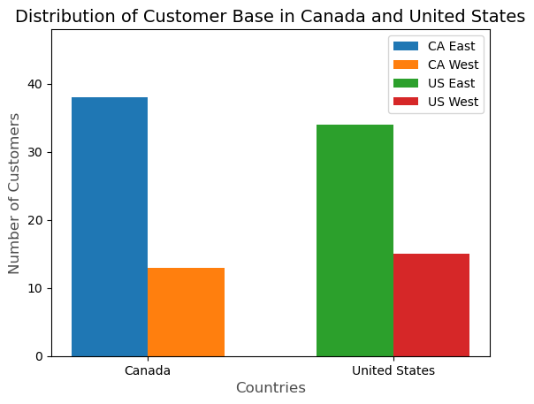

```python
plt.bar(x=range(0,2),height=table["CA EAST"],width = 0.5,label="CA East")
plt.bar(x=[0.5,1.5],height=table["CA WEST"],width = 0.5,label="CA West")
plt.bar(x=[0.6,1.6],height=table["US EAST"],width = 0.5,label="US East")
plt.bar(x=[1.1,2.1],height=table["US WEST"],width = 0.5,label="US West")
plt.xticks([0.25, 1.85], ['Canada', 'United States'])
plt.ylim([0,48]) # Lim of the y-axis
# plt.yticks([0,1])
plt.title("Distribution of Customer Base in Canada and United States",size=14)
plt.xlabel("Countries",size=12,color="#4c4c4c")
plt.ylabel("Number of Customers",size=12,color="#4c4c4c")
plt.legend()
plt.show()
```

From the above chart we can visualize 3 Key Information

1. **CA EAST** holds the majority of Customer Base in Canada
2. Whereas in the US, **US East** holds the majority share of customers for Sarah Tees.
3. Conclusively, **Canada East** and **US East** constitutes their majority of Customer base in North America

#### Distibution of Current Year Sales by Country and Region

```python
table1 = pd.pivot_table(data,index=["COUNTRY","REGION"],values="YTD_SALES",aggfunc="sum")
table1.reset_index(inplace=True)
table1
```

|  | COUNTRY | REGION | YTD_SALES |
| --- | --- | --- | --- |
| 0 | CA | CA EAST | 648.107092 |
| 1 | CA | CA WEST | 335.999420 |
| 2 | US | US EAST | 1019.058150 |
| 3 | US | US WEST | 892.765430 |

```python
x = px.bar(data_frame=table1,x="REGION",y="YTD_SALES",color="COUNTRY",template="simple_white",title="2023 Sales in Canada and United States",width= 800)
x["data"][0]["marker"]["color"] = "#EF3340"
x["data"][1]["marker"]["color"] = "#002868"
x
```

[interactive chart not shown]

### This might be an area of special attention

Why Canada East has fewer sales units inspite of having more customer base??  
Also How come US West having less customer base has higher sales??

```python
table2 = pd.pivot_table(data,index=["COUNTRY","REGION"],values="PRE_YTD_SALES",aggfunc="sum")
table2.reset_index(inplace=True)
table2
```

|  | COUNTRY | REGION | PRE_YTD_SALES |
| --- | --- | --- | --- |
| 0 | CA | CA EAST | 454.42657 |
| 1 | CA | CA WEST | 289.21116 |
| 2 | US | US EAST | 809.42146 |
| 3 | US | US WEST | 740.66082 |

```python
x = px.bar(data_frame=table2,x="REGION",y="PRE_YTD_SALES",color="COUNTRY",template="simple_white",title="2022 Sales in Canada and United States",width= 800)
x["data"][0]["marker"]["color"] = "#EF3340"
x["data"][1]["marker"]["color"] = "#002868"
x
```

[interactive chart not shown]

The Same trend of Sales pattern is observed in the 2022 year sales. Sales in Canada is less than United States.

```python
table3 = pd.pivot_table(data,index=["COUNTRY","REGION"],values=["PRE_YTD_SALES","YTD_SALES"],aggfunc="sum")
table3.reset_index(inplace=True)
table3
```

|  | COUNTRY | REGION | PRE_YTD_SALES | YTD_SALES |
| --- | --- | --- | --- | --- |
| 0 | CA | CA EAST | 454.42657 | 648.107092 |
| 1 | CA | CA WEST | 289.21116 | 335.999420 |
| 2 | US | US EAST | 809.42146 | 1019.058150 |
| 3 | US | US WEST | 740.66082 | 892.765430 |

```python
x = px.bar(data_frame=table3,x="REGION",y=["PRE_YTD_SALES","YTD_SALES"],barmode="group",template="simple_white",title="Current (2023) and Previous (2022) Year Sales in Canada and United States",width= 800,
          labels=dict(value="Sales in 1000 units $",variable="Sales Type"))
x["data"][0]["marker"]["color"] = "#ecd400"
x["data"][1]["marker"]["color"] = "#101820"
x
```

[interactive chart not shown]

It is quite evident that there is a **growth in YoY sales** in all regions of Canada and United States. However, there is a **relatively higher jump** in YoY Sales in **CA EAST** and **US EAST**

### Lets now evaluate the same sales through the lens of Customer Category

```python
table4 = pd.pivot_table(data,index=["COUNTRY","REGION","CUSTOMER_CATEGORY"],values=["PRE_YTD_SALES","YTD_SALES"],aggfunc="sum")
table4.reset_index(inplace=True)
table4
```

|  | COUNTRY | REGION | CUSTOMER_CATEGORY | PRE_YTD_SALES | YTD_SALES |
| --- | --- | --- | --- | --- | --- |
| 0 | CA | CA EAST | Corporate | 152.78491 | 232.472820 |
| 1 | CA | CA EAST | End Customer | 45.68353 | 115.651722 |
| 2 | CA | CA EAST | Reseller | 255.95813 | 299.982550 |
| 3 | CA | CA WEST | Corporate | 80.06572 | 100.409440 |
| 4 | CA | CA WEST | End Customer | 13.64991 | 17.340350 |
| 5 | CA | CA WEST | Reseller | 195.49553 | 218.249630 |
| 6 | US | US EAST | Corporate | 217.23747 | 370.432550 |
| 7 | US | US EAST | End Customer | 52.88671 | 41.312240 |
| 8 | US | US EAST | Reseller | 539.29728 | 607.313360 |
| 9 | US | US WEST | Corporate | 153.77069 | 282.641630 |
| 10 | US | US WEST | End Customer | 6.33372 | 14.165910 |
| 11 | US | US WEST | Reseller | 580.55641 | 595.957890 |

```python
x = px.bar(data_frame=table4,x="CUSTOMER_CATEGORY",y="YTD_SALES",color="CUSTOMER_CATEGORY",template="simple_white",title="2023 Sales By Region and Customer Segment",width= 800,facet_col="REGION",facet_col_wrap=2)
x["data"][0]["marker"]["color"] = "#408EC6"
x["data"][1]["marker"]["color"] = "#408EC6"
x["data"][2]["marker"]["color"] = "#408EC6"
x["data"][3]["marker"]["color"] = "#408EC6"

x["data"][4]["marker"]["color"] = "#7A2048"
x["data"][5]["marker"]["color"] = "#7A2048"
x["data"][6]["marker"]["color"] = "#7A2048"
x["data"][7]["marker"]["color"] = "#7A2048"

x["data"][8]["marker"]["color"] = "#1E2761"
x["data"][9]["marker"]["color"] = "#1E2761"
x["data"][10]["marker"]["color"] = "#1E2761"
x["data"][11]["marker"]["color"] = "#1E2761"
x
```

[interactive chart not shown]

```python
table5 = pd.pivot_table(data,index=["COUNTRY","REGION","CUSTOMER_CATEGORY"],values=["PRE_YTD_SALES","YTD_SALES","ACCOUNT_ID"],aggfunc={'ACCOUNT_ID': "count", 'PRE_YTD_SALES': "sum",'YTD_SALES': "sum"})
table5.reset_index(inplace=True)
table5
```

|  | COUNTRY | REGION | CUSTOMER_CATEGORY | ACCOUNT_ID | PRE_YTD_SALES | YTD_SALES |
| --- | --- | --- | --- | --- | --- | --- |
| 0 | CA | CA EAST | Corporate | 5 | 152.78491 | 232.472820 |
| 1 | CA | CA EAST | End Customer | 31 | 45.68353 | 115.651722 |
| 2 | CA | CA EAST | Reseller | 2 | 255.95813 | 299.982550 |
| 3 | CA | CA WEST | Corporate | 2 | 80.06572 | 100.409440 |
| 4 | CA | CA WEST | End Customer | 9 | 13.64991 | 17.340350 |
| 5 | CA | CA WEST | Reseller | 2 | 195.49553 | 218.249630 |
| 6 | US | US EAST | Corporate | 9 | 217.23747 | 370.432550 |
| 7 | US | US EAST | End Customer | 21 | 52.88671 | 41.312240 |
| 8 | US | US EAST | Reseller | 4 | 539.29728 | 607.313360 |
| 9 | US | US WEST | Corporate | 5 | 153.77069 | 282.641630 |
| 10 | US | US WEST | End Customer | 6 | 6.33372 | 14.165910 |
| 11 | US | US WEST | Reseller | 4 | 580.55641 | 595.957890 |

### Distribution of Customer base by region and Customer Segment

```python
x = px.bar(data_frame=table5,x="CUSTOMER_CATEGORY",y="ACCOUNT_ID",color="CUSTOMER_CATEGORY",template="simple_white",title="Distribution of Customer base by Region and Customer Segment",
           width= 800,facet_col="REGION",facet_col_wrap=2,labels=dict(ACCOUNT_ID = "Number of Customers",CUSTOMER_CATEGORY = "Customer Type"))
x["data"][0]["marker"]["color"] = "#E3B448"
x["data"][1]["marker"]["color"] = "#E3B448"
x["data"][2]["marker"]["color"] = "#E3B448"
x["data"][3]["marker"]["color"] = "#E3B448"

x["data"][4]["marker"]["color"] = "#3A6B35"
x["data"][5]["marker"]["color"] = "#3A6B35"
x["data"][6]["marker"]["color"] = "#3A6B35"
x["data"][7]["marker"]["color"] = "#3A6B35"

x["data"][8]["marker"]["color"] = "#fd00c9"
x["data"][9]["marker"]["color"] = "#fd00c9"
x["data"][10]["marker"]["color"] = "#fd00c9"
x["data"][11]["marker"]["color"] = "#fd00c9"
x
```

[interactive chart not shown]

It is important to note that **CA EAST** and **US EAST** have a **high number of End Customers** to handle. It also clarifies that due to **less number of resellers in CA EAST** it demonstrates **dip in Sales units** for 2023.

##### Also a similar trend is depicted across Number of Customer Distribution in East Regions and West Regions

Where East Regions have relatively more End Customers than other customer segments.

Lets move on from Region & Customer Segment to Sales leader and Sales VP

### Overall Performance of Sales Leaders

```python
table6 = pd.pivot_table(data,index=["SALES_VICE_PRESIDENT","SALES_LEADER","COUNTRY","REGION"],values=["PRE_YTD_SALES","YTD_SALES","ACCOUNT_ID"],aggfunc={'ACCOUNT_ID': "count", 'PRE_YTD_SALES': "sum",'YTD_SALES': "sum"})
table6.reset_index(inplace=True)
table6
```

|  | SALES_VICE_PRESIDENT | SALES_LEADER | COUNTRY | REGION | ACCOUNT_ID | PRE_YTD_SALES | YTD_SALES |
| --- | --- | --- | --- | --- | --- | --- | --- |
| 0 | Adem Osborne | Iram Luna | CA | CA EAST | 25 | 313.36623 | 438.091032 |
| 1 | Adem Osborne | Shahzaib Mahoney | CA | CA EAST | 13 | 141.06034 | 210.016060 |
| 2 | Esa Walton | Zaid Nunez | CA | CA WEST | 13 | 289.21116 | 335.999420 |
| 3 | Hattie Beattie | Nicole Stamp | US | US EAST | 34 | 809.42146 | 1019.058150 |
| 4 | Matas Walmsley | Atlanta Avila | US | US WEST | 3 | 38.70184 | 60.601290 |
| 5 | Matas Walmsley | Taliah Pope | US | US WEST | 12 | 701.95898 | 832.164140 |

#### Performance of Sales Leader for 2023

```python
x = px.bar(data_frame=table6,x="SALES_LEADER",y="YTD_SALES",color="COUNTRY",template="simple_white",title="Sales Leader Performance in 2023",width= 800)
x["data"][0]["marker"]["color"] = "#EF3340"
x["data"][1]["marker"]["color"] = "#002868"
x
```

[interactive chart not shown]

We can deduce that **Iram Luna** brought the highest Sales for **Canada** with 438K Sales  
Whereas in the US, **Nicole Stamp** brought the highest Sales for **US** with 1000K+ Sales

```python
x = px.bar(data_frame=table6,x="SALES_LEADER",y="ACCOUNT_ID",color="REGION",template="simple_white",title="Sales Leader - Client Engagement in 2023",width= 800)
x["data"][0]["marker"]["color"] = "#721817"
x["data"][1]["marker"]["color"] = "#fa9f42"
x["data"][2]["marker"]["color"] = "#2b4162"
x["data"][3]["marker"]["color"] = "#0b6e4f"
x
```

[interactive chart not shown]

```python
x = px.bar(data_frame=table6,x="SALES_LEADER",y="YTD_SALES",color="REGION",template="plotly_dark",title="Sales Leader Performance by Region in 2023",width= 800)
x["data"][0]["marker"]["color"] = "#a63446"
x["data"][1]["marker"]["color"] = "#fbfef9"
x["data"][2]["marker"]["color"] = "#0c6291"
x["data"][3]["marker"]["color"] = "#8eedf7"
x
```

[interactive chart not shown]

We could visualize that **Nicole Stamp** was the best Performer for the Sarah Brand as She generated a little over 1000K Sales despite being the only **Sales Leader for the US East Region**

It is quite evident that **Nicole Stamp** handled the *highest number of clients* and was successfull to **solely** drive highest Sales in her Region.

On the other hand, despite of having **2 Sales Leader** in **CA EAST**, Sarah brand was unable to drive substantial sales in the region.

### Let's further investigate which customer segment is pumping sales for each Sales Leader

```python
table7 = pd.pivot_table(data,index=["SALES_VICE_PRESIDENT","SALES_LEADER","COUNTRY","REGION","CUSTOMER_CATEGORY"],values=["PRE_YTD_SALES","YTD_SALES","ACCOUNT_ID"],aggfunc={'ACCOUNT_ID': "count", 'PRE_YTD_SALES': "sum",'YTD_SALES': "sum"})
table7.reset_index(inplace=True)
table7
```

|  | SALES_VICE_PRESIDENT | SALES_LEADER | COUNTRY | REGION | CUSTOMER_CATEGORY | ACCOUNT_ID | PRE_YTD_SALES | YTD_SALES |
| --- | --- | --- | --- | --- | --- | --- | --- | --- |
| 0 | Adem Osborne | Iram Luna | CA | CA EAST | Corporate | 4 | 131.52915 | 192.025080 |
| 1 | Adem Osborne | Iram Luna | CA | CA EAST | End Customer | 20 | 30.08893 | 94.372902 |
| 2 | Adem Osborne | Iram Luna | CA | CA EAST | Reseller | 1 | 151.74815 | 151.693050 |
| 3 | Adem Osborne | Shahzaib Mahoney | CA | CA EAST | Corporate | 1 | 21.25576 | 40.447740 |
| 4 | Adem Osborne | Shahzaib Mahoney | CA | CA EAST | End Customer | 11 | 15.59460 | 21.278820 |
| 5 | Adem Osborne | Shahzaib Mahoney | CA | CA EAST | Reseller | 1 | 104.20998 | 148.289500 |
| 6 | Esa Walton | Zaid Nunez | CA | CA WEST | Corporate | 2 | 80.06572 | 100.409440 |
| 7 | Esa Walton | Zaid Nunez | CA | CA WEST | End Customer | 9 | 13.64991 | 17.340350 |
| 8 | Esa Walton | Zaid Nunez | CA | CA WEST | Reseller | 2 | 195.49553 | 218.249630 |
| 9 | Hattie Beattie | Nicole Stamp | US | US EAST | Corporate | 9 | 217.23747 | 370.432550 |
| 10 | Hattie Beattie | Nicole Stamp | US | US EAST | End Customer | 21 | 52.88671 | 41.312240 |
| 11 | Hattie Beattie | Nicole Stamp | US | US EAST | Reseller | 4 | 539.29728 | 607.313360 |
| 12 | Matas Walmsley | Atlanta Avila | US | US WEST | Corporate | 1 | 36.64361 | 55.899930 |
| 13 | Matas Walmsley | Atlanta Avila | US | US WEST | End Customer | 2 | 2.05823 | 4.701360 |
| 14 | Matas Walmsley | Taliah Pope | US | US WEST | Corporate | 4 | 117.12708 | 226.741700 |
| 15 | Matas Walmsley | Taliah Pope | US | US WEST | End Customer | 4 | 4.27549 | 9.464550 |
| 16 | Matas Walmsley | Taliah Pope | US | US WEST | Reseller | 4 | 580.55641 | 595.957890 |

```python
x = px.bar(data_frame=table7,x="SALES_LEADER",y="YTD_SALES",color="CUSTOMER_CATEGORY",template="simple_white",title="Sales Performance by Consumer Category and Sales Leader in 2023",width= 800,barmode="group")
x["data"][0]["marker"]["color"] = "#002626"
x["data"][1]["marker"]["color"] = "#0e4749"
x["data"][2]["marker"]["color"] = "#95c623"
x
```

[interactive chart not shown]

It is interesting to note here that **Atlanta Avila** was the **least performer** in the **US** as she was **unable to hold any "reseller"** from her region on the contrary *Taliah Pope was able to generate hefty sales from "Reseller" and "Corporate" Consumer Segments*

```python
x = px.bar(data_frame=table6,x="SALES_LEADER",y=["PRE_YTD_SALES","YTD_SALES"],template="simple_white",title="Sales Leader Performance Comparision in 2023",width= 800,barmode="group"
           ,labels=dict(value="Sales in 1000 Units",variable="Sale Period"))
x["data"][0]["marker"]["color"] = "#642ca9"
x["data"][1]["marker"]["color"] = "#ff36ab"
x
```

[interactive chart not shown]

It is noted that every sales leader have improved on a YoY basis leading to overall increment in sales by region which was seen earlier

### Other Aspect to Investigate here is -

How old the customer has been with Sarah

```python
table8 = pd.pivot_table(data,index=["COUNTRY","REGION","CUSTOMER_CATEGORY"],values=["ACCOUNT_ID","ACCOUNT_AGE_YEARS"],aggfunc={'ACCOUNT_ID': "count","ACCOUNT_AGE_YEARS":"mean" })
table8.reset_index(inplace=True)
table8
```

|  | COUNTRY | REGION | CUSTOMER_CATEGORY | ACCOUNT_AGE_YEARS | ACCOUNT_ID |
| --- | --- | --- | --- | --- | --- |
| 0 | CA | CA EAST | Corporate | 5.200000 | 5 |
| 1 | CA | CA EAST | End Customer | 4.774194 | 31 |
| 2 | CA | CA EAST | Reseller | 5.000000 | 2 |
| 3 | CA | CA WEST | Corporate | 3.500000 | 2 |
| 4 | CA | CA WEST | End Customer | 5.000000 | 9 |
| 5 | CA | CA WEST | Reseller | 3.500000 | 2 |
| 6 | US | US EAST | Corporate | 4.888889 | 9 |
| 7 | US | US EAST | End Customer | 5.238095 | 21 |
| 8 | US | US EAST | Reseller | 5.250000 | 4 |
| 9 | US | US WEST | Corporate | 5.800000 | 5 |
| 10 | US | US WEST | End Customer | 7.000000 | 6 |
| 11 | US | US WEST | Reseller | 5.750000 | 4 |

```python
x = px.bar(data_frame=table8,x="CUSTOMER_CATEGORY",y="ACCOUNT_AGE_YEARS",template="simple_white",title="Sales Leader Performance Comparision in 2023",facet_col="REGION",barmode="group")
x["data"][0]["marker"]["color"] = "#2a2d34"
x["data"][1]["marker"]["color"] = "#009ddc"
x["data"][2]["marker"]["color"] = "#f26430"
x["data"][3]["marker"]["color"] = "#6761a8"
x
```

[interactive chart not shown]

It noteworthy that Sarah's brand has been operating in the **US WEST Region** from a longer time duration more than **5+** years which helps understand the high sales units due to longer period in the market.

It should also be considered that **Corporate and Reseller Segment** in **CA WEST Region** seems to be a **newer region** being operated however, it has shown **tremendous potential** in the Current and Previous Year Sales.

### Section 6 : Lets Now Analyze Account Level Information

```python
fig = px.box(df, x="CUSTOMER_CATEGORY", y="YTD_SALES")
fig.show()
```

[interactive chart not shown]

It is prominent and obvious that Corporates have higher sales than End Customers and Resellers have higher sales than Corporate Segments

Some important transactions to note here is the **outlier of the "End Customer" and "Corporate"** which tends to give orders like Corporate and Reseller Segment Respectively.

#### Lets Investigate Accounts whose Current Sales were lower than Previous years

```python
px.scatter(df,"PRE_YTD_SALES","YTD_SALES",facet_col="REGION",facet_col_wrap=2)
```

[interactive chart not shown]

Resellers have **higher budgets** than anyone else, So for them drop of *40% or higher is concerning*  
Corporates have **higher budgets than end customers** so,  
if the dip in corporates is *greater than 20%* then it is *concerning*  
For End Customers if the dip is *greater than 10%* the Previous year then it is *concerning*  
**Lets calculate Percentage Change**

```python
df["Percentage_Loss_Status"] =""
for i in df.index:
    if df.loc[i,"CUSTOMER_CATEGORY"] == "Corporate ":
        if (df.loc[i,"YTD_SALES"] - df.loc[i,"PRE_YTD_SALES"])*100/df.loc[i,"PRE_YTD_SALES"] < -20:
            df.loc[i,"Percentage_Loss_Status"] = "Concerning"
        else:
            df.loc[i,"Percentage_Loss_Status"] = "Normal"

    elif df.loc[i,"CUSTOMER_CATEGORY"] == "End Customer":
        if (df.loc[i,"YTD_SALES"] - df.loc[i,"PRE_YTD_SALES"])*100/df.loc[i,"PRE_YTD_SALES"] < -10:
            df.loc[i,"Percentage_Loss_Status"] = "Concerning"
        else:
            df.loc[i,"Percentage_Loss_Status"] = "Normal"

    else:
        if (df.loc[i,"YTD_SALES"] - df.loc[i,"PRE_YTD_SALES"])*100/df.loc[i,"PRE_YTD_SALES"] < -40:
            df.loc[i,"Percentage_Loss_Status"] = "Concerning"
        else:
            df.loc[i,"Percentage_Loss_Status"] = "Normal"
df["Percentage_Loss_Status"].value_counts()
```

[output not shown]

```python
conc_acc = df[df["Percentage_Loss_Status"]=="Concerning"]
conc_acc.reset_index(inplace=True)
conc_acc
```

[output not shown]

These are the list of accounts which require special attention. As their sales drop seems to be concerning.  
**Note:** Most of the concerning accounts are "End Customers" which consitute a **relatively lesser share** in Sales. But the **Resellers** and **Corporate** accounts holds a **substantial share in sales** which should be given **more attention**

Consistent Depletion of sales of these customers will be a major area of concern. Thus Sarah shall send surveys to gather feedback and encompass their feedback by devising strategies to regain the customers who are losing interest in their business.

## Section 7 : Gist of Insights Derived from Visualizations

### Overall View of Regions and their Sales Leader

### Below is the SWOT Analysis of Regions

[figure not shown]

### Below is the Performance Quadrant for the Sales Leader

[figure not shown]

### Author : Tirth Raval

### Email : ravalt1@mcmaster.ca

### Student ID : 400487318